# R Studio Exercise 3: Logistic regression

*November 13, 2019*  
*This week I have performed a data wrangling on a joined dataset and did logistic regression.*

### **Our dataset**

Reading a file and attaching the needed libraries (dplyr gives some little error but works fine):

```r
setwd("~/IODS-project/data")
library(ggplot2)
library(dplyr)
library(boot)
joineddata <- read.table("joineddata.csv")
```

Printing out variable names:

```r
colnames(joineddata)
```

```
##  [1] "school"     "sex"        "age"        "address"    "famsize"
##  [6] "Pstatus"    "Medu"       "Fedu"       "Mjob"       "Fjob"
## [11] "reason"     "nursery"    "internet"   "guardian"   "traveltime"
## [16] "studytime"  "failures"   "schoolsup"  "famsup"     "paid"
## [21] "activities" "higher"     "romantic"   "famrel"     "freetime"
## [26] "goout"      "Dalc"       "Walc"       "health"     "absences"
## [31] "G1"         "G2"         "G3"         "alc_use"    "high_use"
```

This is data from two questionnaires related to student performance (including alcohol consumption).  
The dataset consists of 382 observations (rows) and 35 variables (columns).

### **Lets hypothesise**

1. Alcohol consumption and **gender** are related: males consume more alcohol, than females.
2. Alcohol consumption and **first period grade** are related: greater first grade means less alcohol consumption for both genders.
3. Alcohol consumption and **second period grade** are related: greater second grade means less alcohol consumption for both genders.
4. Alcohol consumption and **third period grade** are related: greater third grade means less alcohol consumption for both genders.

### **Exploring the variables**

Before looking at variables, lets look at the alcohol consumption distribution:

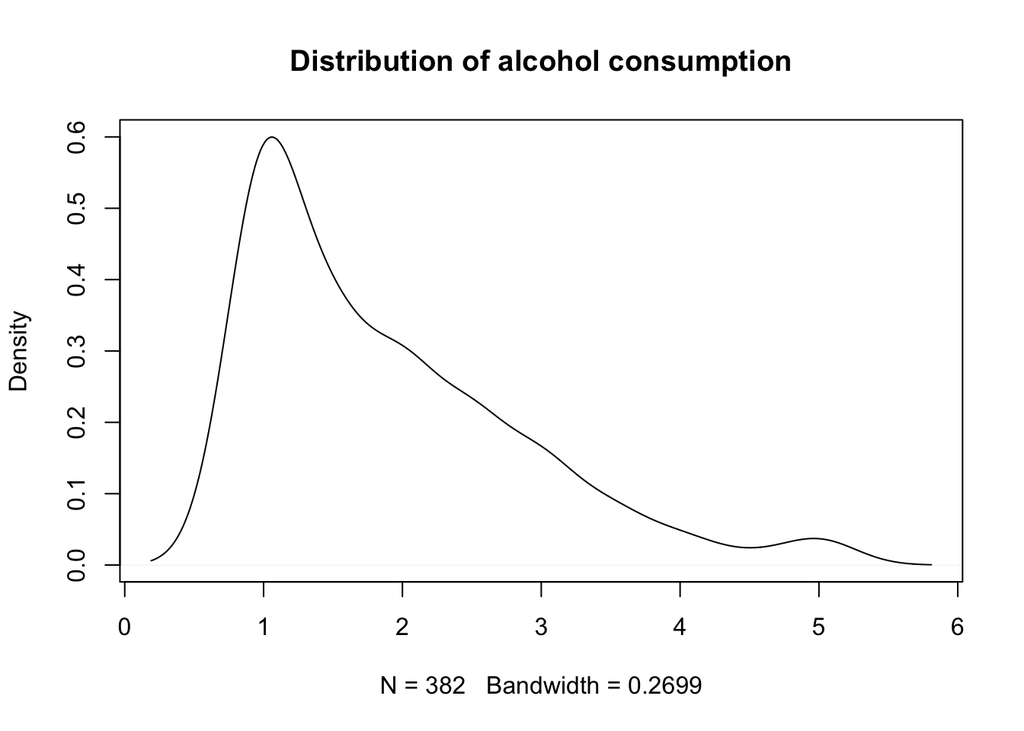

```r
plot(density(joineddata$alc_use), main = "Distribution of alcohol consumption")
```

We can see that the consumption is mostly low across all dataframe.

Now lets do some numerical exploration:

**Gender**

```r
summary(joineddata$sex)
```

```
##   F   M
## 198 184
```

We can see relatively equal amount of males and females.

**First period grades**

```r
summary(joineddata$G1)
```

```
##    Min. 1st Qu.  Median    Mean 3rd Qu.    Max.
##    2.00   10.00   12.00   11.49   14.00   18.00
```

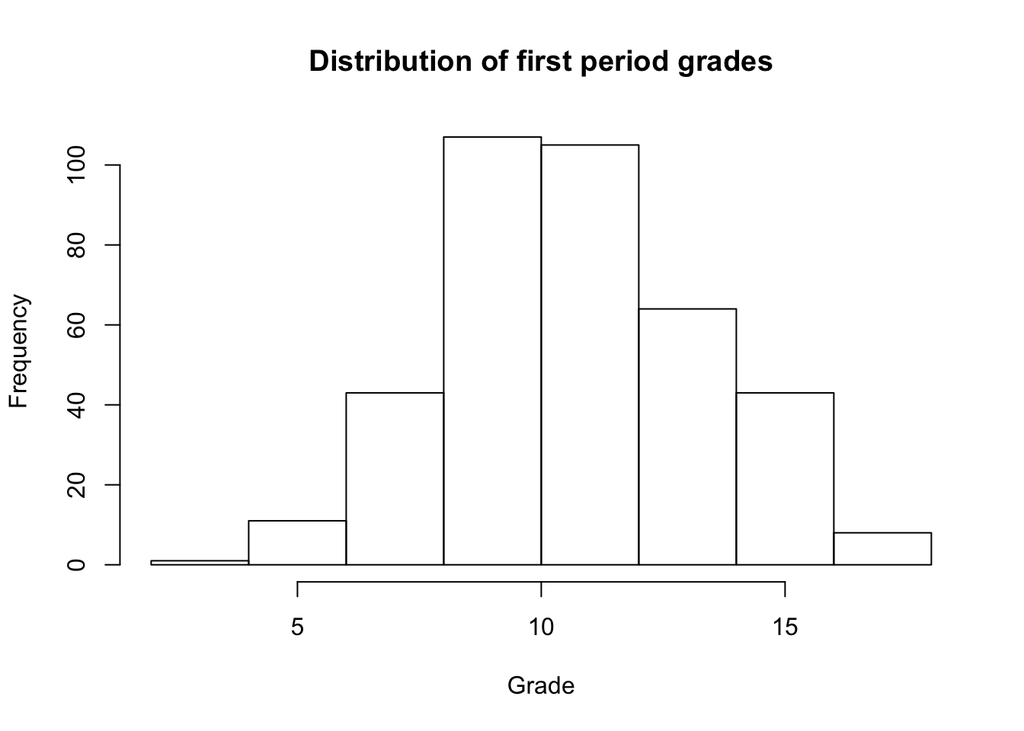

```r
hist(joineddata$G1, main = "Distribution of first period grades", xlab = "Grade")
```

Distribution of first period grades is normal.

**Second period grades**

```r
summary(joineddata$G2)
```

```
##    Min. 1st Qu.  Median    Mean 3rd Qu.    Max.
##    4.00   10.00   12.00   11.47   14.00   18.00
```

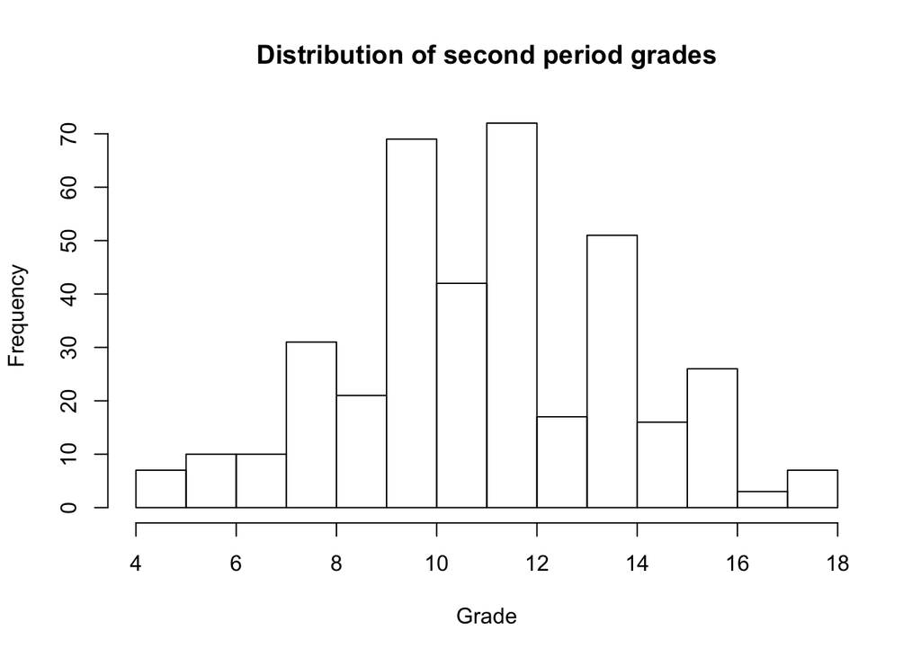

```r
hist(joineddata$G2, main = "Distribution of second period grades", xlab = "Grade")
```

Distribution of second period grades is normal.

**Final grades**

```r
summary(joineddata$G3)
```

```
##    Min. 1st Qu.  Median    Mean 3rd Qu.    Max.
##    0.00   10.00   12.00   11.46   14.00   18.00
```

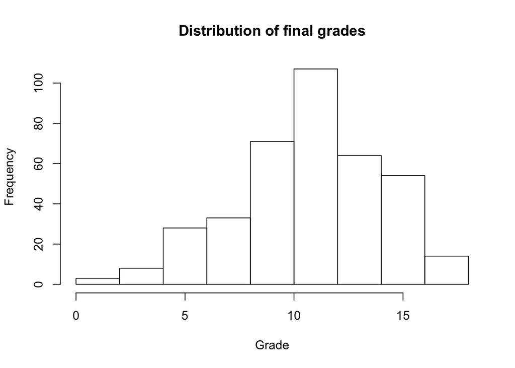

```r
hist(joineddata$G3, main = "Distribution of final grades", xlab = "Grade")
```

Distribution of final grades is normal.

Now it’s time for graphical exploration:

**Hypothesis 1**: males consume more alcohol, than females.

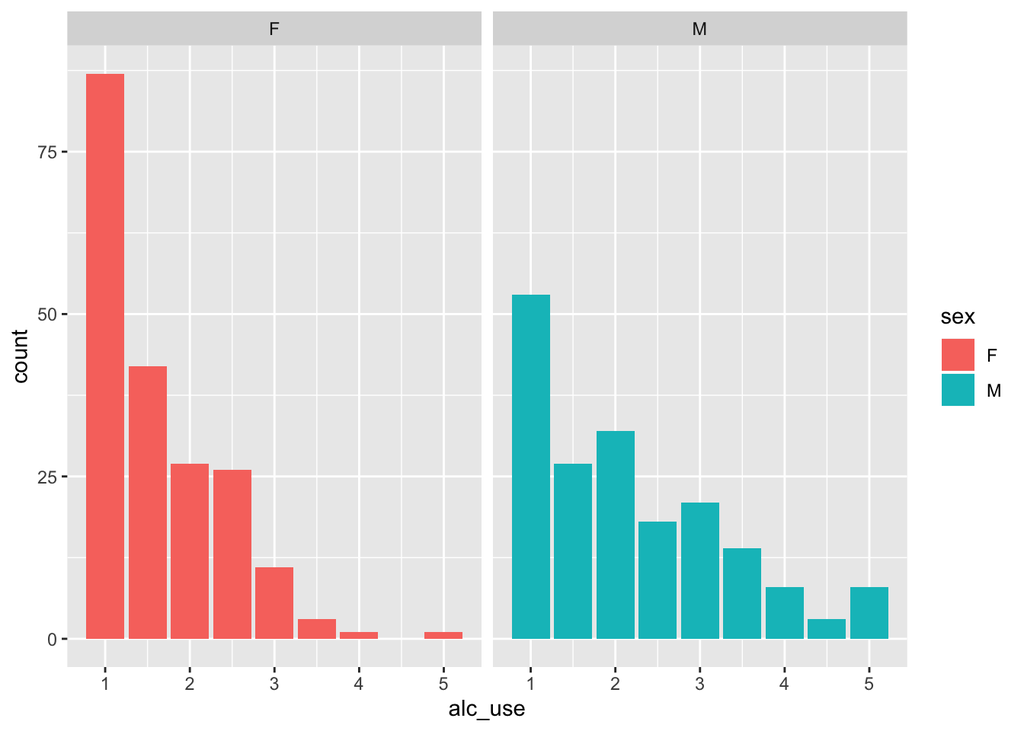

```r
g1 <- ggplot(data = joineddata, aes(x = alc_use, fill = sex))
g1 + geom_bar() + facet_wrap("sex")
```

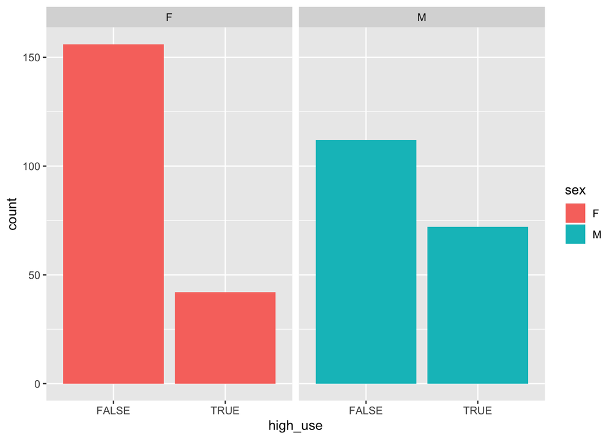

```r
g1 <- ggplot(data = joineddata, aes(x = high_use, fill = sex))
g1 + geom_bar() + facet_wrap("sex")
```

This bar graph confirms the previous explanation, women don’t consume much.  
**Conclusion**: my hypothesis can be partly confirmed.

**Hypothesis 2**: greater first grade means less alcohol consumption for both genders.

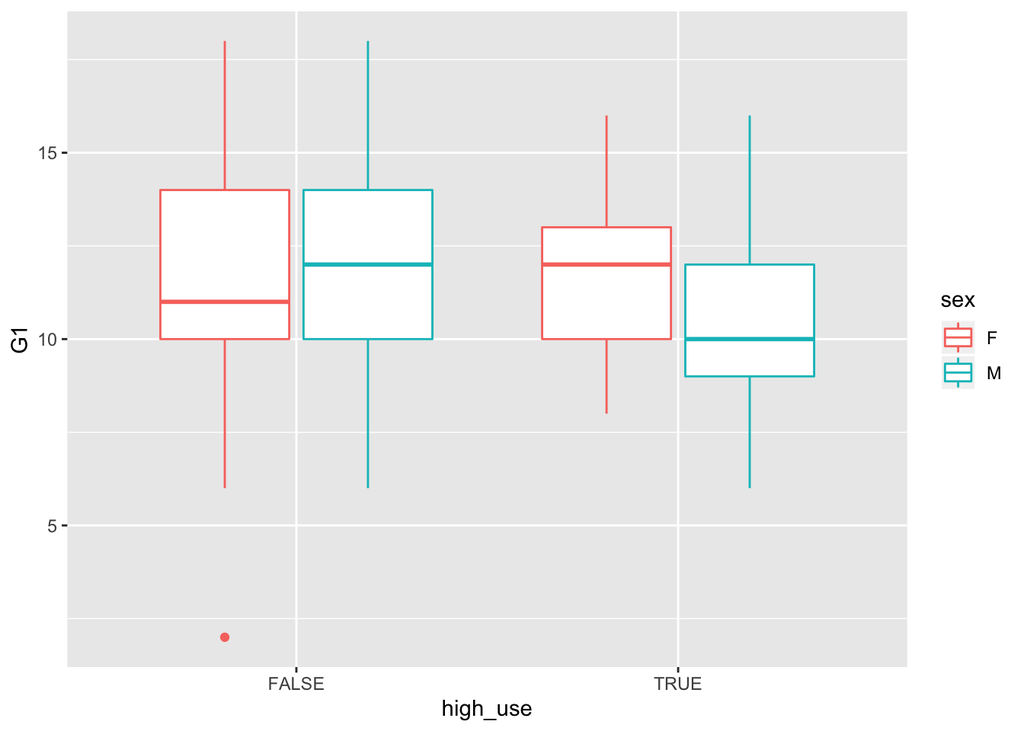

```r
g3 <- ggplot(joineddata, aes(x = high_use, y = G1, col = sex))
g3 + geom_boxplot()
```

There is no difference between girls whose consumption is high or low.  
However, boys who consume more have lower grades.  
**Conclusion**: my hypothesis can be partly confirmed (for boys).

**Hypothesis 3**: greater second grade means less alcohol consumption for both genders.

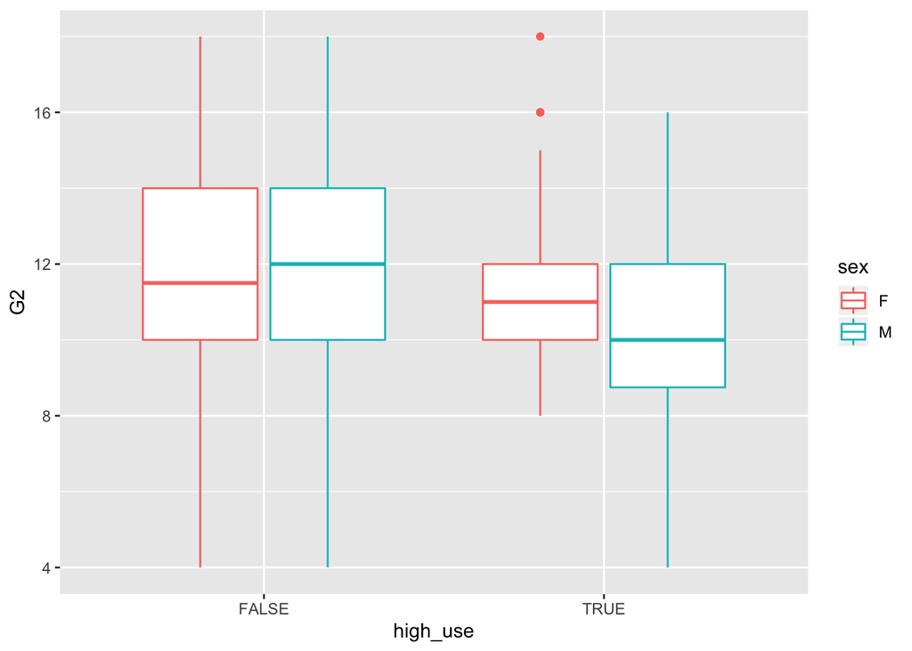

```r
g4 <- ggplot(joineddata, aes(x = high_use, y = G2, col = sex))
g4 + geom_boxplot()
```

Visually there is almost no difference between girls, but it may change after removing an outlier.  
Visually, boys who consume more have lower grades.  
**Conclusion**: my hypothesis can be partly confirmed (for boys).

**Hypothesis 4**: greater final grade means less alcohol consumption for both genders.

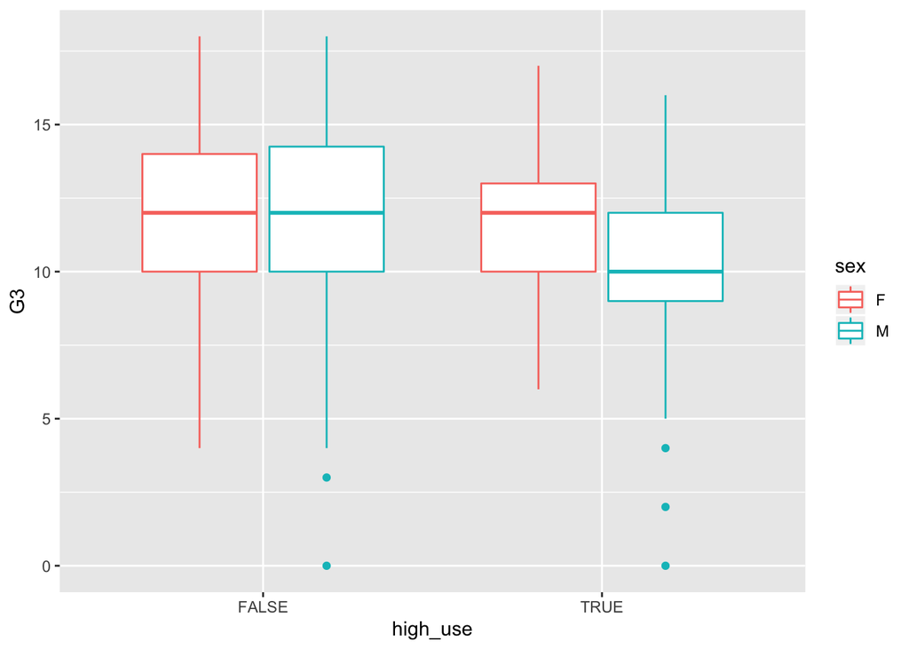

```r
g5 <- ggplot(joineddata, aes(x = high_use, y = G3, col = sex))
g5 + geom_boxplot()
```

### **Logistic regression**

```r
m <- glm(high_use ~ sex + G1 + G2 + G3, data = joineddata, family = "binomial")
summary(m)
```

```
##
## Call:
## glm(formula = high_use ~ sex + G1 + G2 + G3, family = "binomial",
##     data = joineddata)
##
## Deviance Residuals:
##     Min       1Q   Median       3Q      Max
## -1.2828  -0.8657  -0.6845   1.2340   2.0382
##
## Coefficients:
##              Estimate Std. Error z value Pr(>|z|)
## (Intercept)  0.140881   0.530729   0.265 0.790664
## sexM         0.883365   0.233216   3.788 0.000152 ***
## G1          -0.120940   0.094241  -1.283 0.199385
## G2          -0.010811   0.116916  -0.092 0.926328
## G3           0.002673   0.086031   0.031 0.975211
## ---
## Signif. codes:  0 '***' 0.001 '**' 0.01 '*' 0.05 '.' 0.1 ' ' 1
##
## (Dispersion parameter for binomial family taken to be 1)
##
##     Null deviance: 465.68  on 381  degrees of freedom
## Residual deviance: 442.10  on 377  degrees of freedom
## AIC: 452.1
##
## Number of Fisher Scoring iterations: 4
```

Lets look at model’s coefficients:

```r
coef(m)
```

```
## (Intercept)        sexM          G1          G2          G3
##  0.14088116  0.88336501 -0.12093983 -0.01081064  0.00267323
```

And odds ratios:

```r
OR <- coef(m) %>% exp
OR
```

```
## (Intercept)        sexM          G1          G2          G3
##   1.1512878   2.4190261   0.8860873   0.9892476   1.0026768
```

And confidence intervals:

```r
CI <- confint(m) %>% exp
CI
```

```
##                 2.5 %   97.5 %
## (Intercept) 0.4066194 3.274532
## sexM        1.5383105 3.843873
## G1          0.7350499 1.065697
## G2          0.7864414 1.246077
## G3          0.8475937 1.190283
```

Now lets look at all them:

```r
cbind(OR, CI)
```

```
##                    OR     2.5 %   97.5 %
## (Intercept) 1.1512878 0.4066194 3.274532
## sexM        2.4190261 1.5383105 3.843873
## G1          0.8860873 0.7350499 1.065697
## G2          0.9892476 0.7864414 1.246077
## G3          1.0026768 0.8475937 1.190283
```

### **Predictive power**

I am only using the “sex” and the “G3” now.

```r
m <- glm(high_use ~ sex + G3, data = joineddata, family = "binomial")
summary(m)
```

```
##
## Call:
## glm(formula = high_use ~ sex + G3, family = "binomial", data = joineddata)
##
## Deviance Residuals:
##     Min       1Q   Median       3Q      Max
## -1.4158  -0.8453  -0.6698   1.2796   1.9827
##
## Coefficients:
##             Estimate Std. Error z value Pr(>|z|)
## (Intercept) -0.33776    0.41861  -0.807 0.419757
## sexM         0.88254    0.23246   3.796 0.000147 ***
## G3          -0.08688    0.03466  -2.507 0.012189 *
## ---
## Signif. codes:  0 '***' 0.001 '**' 0.01 '*' 0.05 '.' 0.1 ' ' 1
##
## (Dispersion parameter for binomial family taken to be 1)
##
##     Null deviance: 465.68  on 381  degrees of freedom
## Residual deviance: 444.55  on 379  degrees of freedom
## AIC: 450.55
##
## Number of Fisher Scoring iterations: 4
```

Both variables are significant.

```r
probabilities <- predict(m, type = "response")
joineddata <- mutate(joineddata, probability = probabilities)
joineddata <- mutate(joineddata, prediction = probability > 0.5)
select(joineddata, sex, G3, high_use, probability, prediction) %>% tail(10)
```

```
##     sex G3 high_use probability prediction
## 373   M  0    FALSE   0.6329243       TRUE
## 374   M  2     TRUE   0.5917072       TRUE
## 375   F 12    FALSE   0.2009626      FALSE
## 376   F  8    FALSE   0.2625459      FALSE
## 377   F  5    FALSE   0.3160153      FALSE
## 378   F 12    FALSE   0.2009626      FALSE
## 379   F  4    FALSE   0.3350868      FALSE
## 380   F  4    FALSE   0.3350868      FALSE
## 381   M 13     TRUE   0.3578685      FALSE
## 382   M 10     TRUE   0.4197026      FALSE
```

Now lets do 2x2 cross tabulation:

```r
table(high_use = joineddata$high_use, prediction = joineddata$prediction)
```

```
##         prediction
## high_use FALSE TRUE
##    FALSE   258   10
##    TRUE    104   10
```

And graphic representation:

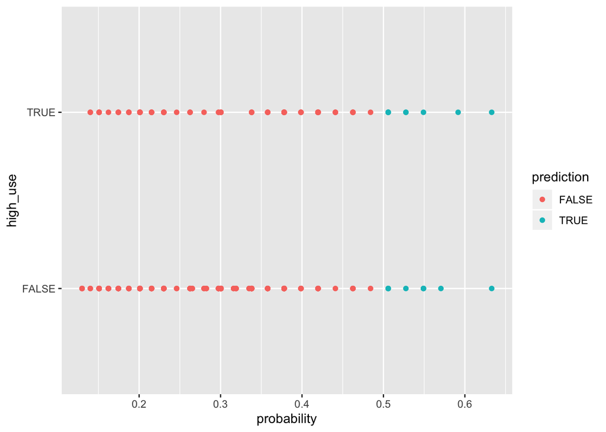

```r
g <- ggplot(joineddata, aes(x = probability, y = high_use, col = prediction))
g + geom_point()
```

Now we can explore the training error:

```r
loss_func <- function(class, prob) {
  n_wrong <- abs(class - prob) > 0.5
  mean(n_wrong)
}
loss_func(class = joineddata$high_use, prob = joineddata$probability)
```

```
## [1] 0.2984293
```

Proportion of incorrect predictions (training error) is almost 30%.

### **BONUS: 10-fold cross-validation**

```r
cv <- cv.glm(data = joineddata, cost = loss_func, glmfit = m, K = 10)
cv$delta[1]
```

```
## [1] 0.3062827
```

The prediction error is 0.30 - it’s a bit worse than DataCamp’s model error.